# 基于灰色系统GM(1,1)模型分析2019-nCoV对意大利旅游经济的影响

卫晓帆 李宇

# 1研究目的

意大利旅游业发达，是世界第五大旅游国。此次疫情的爆发必定对其旅游行业产生很大的冲击。为了定量分析新冠肺炎对2020年意大利旅游收入产生的影响，本次报告使用灰色系统分析方法来进行有关分析。

# 2数据来源

本次数据来源于https://zh.tradingeconomics.com/中有关意大利旅游收入的月度数据。为了避免2008年金融危机对本次分析产生影响，我们选取2009年-2020年的数据。

# 3模型介绍

灰色模型（Grey Model，简称GM），即通过累加、累减等方式把原始数据变换成生成序列，再利用其中的规律进行建模预测的方法，可针对不同问题建立相应的灰色模型，如GM(1,1)，GM(1,m)，GM(n,m)，分别用于一个自变量一个因变量，多个自变量一个因变量，多个自变量多个因变量。模型的优点是可以利用较少的数据进行预测，通过微分方程充分挖掘系统的本质，精度较高，可适用于中短期的预测。 其中，GM（1,1）模型是灰色系统理论中的基本模型，它将无规律的原始数据累加生成后, 使其变为有规律的生成数列，然后建立相应的微分方程模型，从而预测事物未来发展趋势和状态。 根据我们收集的历史数据可以看出，在正常情况下，全年的平均值能较好地反映出意大利旅游收入的变化规律，据此把预测分成两部分： (1)利用灰色理论建立 GM（1,1）模型，由2009- 2019年的平均值预测 2020年平均值； (2)通过历史数据计算每个月的旅游收入与全年总值的关系，从而预测出正常情况下 2020年前4个月的旅游收入。

## GM（1,1）建模步骤：

## ①数据的检验与处理

根据收集的数据计算出2009-2019年意大利旅游收入的平均值，即模型的原始数据列，记为$x^{(0)}=(x^{(0)}(1),x^{(0)}(2),...,x^{(0)}(n))$,计算数列的级比：
$$\lambda={x^{(0)}(k-1)}/{x^{(0)}(k)},k=2,3,...,n$$
若所有级比都落在可容覆盖区间$x=(e^{{-2}/{n+1}},e^{{2}/{n+1}})$内，则数列可建立GM（1,1）模型。否则，需要对数据做适当的变换处理，如平移变换$y^{(0)}(k)=x^{(0)}(k)+c,k=1,2,...,n$，取c使得数据列的级比都落在可容覆盖区间(0.846,1.181)内，因此可以建立GM（1,1）模型。

## ②累加生成

令$x^{(1)}$为$x^{(0)}$的一次累加序列，则$x^{(1)}=(x^{(1)}(1),x^{(1)}(2),...,x^{(1)}(n))$，其中，$x^{(1)}(k)=\sum_{i=1}^{k}{x^{(0)}(i)},k=1,2,...,n$。

## ③均值生成

令$z^{(1)}$为$x^{(1)}$的紧邻均值生成序列，$z^{(1)}=(z^{(1)}(1),z^{(1)}(2),...,z^{(1)}(n))$，其中，$z^{(1)}(k)=1/2(x^{(1)}(k)+x^{(1)}(k+1)),k=1,2,...,n$.

## ④GM（1,1）模型

GM（1,1）模型的灰微分方程为：$x^{(0)}(k)+az^{(1)}(k)=b$。式中，a为发展系数，b为灰作用量，均为待定系数。 设待估参数向量$\hat{a}=[\hat{a},\hat{b}]^T$，则灰微分方程的最小二乘估计参数列满足$\hat{a}=[\hat{a},\hat{b}]^T=(B^TB)^{-1}B^TY$,其中，
$$B=\left[ \begin{matrix} -z^{(1)}(2) &1\\-z^{(1)}(3) &1\\ \vdots &\vdots\\-z^{(1)}(n) &1\end{matrix} \right]$$
$$Y=\left[ \begin{matrix} x^{(0)}(2) \\x^{(0)}(3) \\ \vdots \\x^{(0)}(n) \end{matrix} \right]$$
则此模型的时间响应函数为$x^{(1)}(t)=(x^{(1)}(1)-\frac {b} {a}){\rm e}^{-at}+\frac {b} {a}$,估计出参数a、b以后，可以利用此函数对原始序列进行预测。

## ⑤模型检验

在利用GM（1,1）模型进行预测前，需要进行模型精度和误差的检验，来保证预测的准确性。

### ⑴残差检验

对估计值和实际值的残差进行逐点检验，并计算原始序列$x^{(0)}(i)$与$\hat{x}^{(0)}(i)$的绝对残差序列$\Delta^{(0)}(i)=|x^{(0)}(i)-\hat{x}^{(0)}(i)|$，进而计算其相对残差序列$\phi_i=\frac {\Delta^{(0)}(i)} {x^{(0)}(i)}$，最后得出整个模型的平均相对误差$\bar{\phi}=\frac{1}{n}\sum_{i=1}^{n}{\phi_i}$，将其与给定的残差水平进行比较，若小于给定的残差水平，则称模型为残差合格模型。

### ⑵后验差检验

对残差分布的统计特性进行检验。首先，分别计算原始序列和残差序列的平均值$\bar{X}=\frac{1}{n}\sum_{k=1}^{n}{x^{(0)}(k)}$、方差$S_1=\sqrt{\frac{1}{n}\sum_{k=1}^{n}[{{x^{(0)}(k)-\bar{X}}]^2}}$、残差的均值$\bar{E}=\frac{1}{n-1}\sum_{k=2}^{n}{E(k)}$、残差的方差$S_2=\sqrt{\frac{1}{n-1}\sum_{k=2}^{n}[{{E(k)-\bar{E}}]^2}}$、后验差比值$C=\frac{S_2}{S_1}$、小概率误差$P=P({|E(k)-\bar{E}|<0.6745S_1})$，最后，根据相应标准的临界值的大小，综合评价模型的拟合效果，常用的模型精度判断等级见表1。

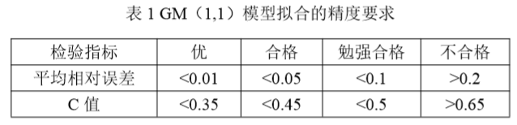

## ⑥预测

根据历史数据计算出2020年每个月的旅游收入占全年总值的比例$u_i$，即$u_i=\sum_{j=1}^{11} {a_{ij}}/\sum_{i=1}^{12} {\sum_{j=1}^{11} {a_{ij}}}$，在得到2020年的预测值后，可算出2020年每个月的旅游收入预测值。

# 4程序介绍

```
## GM(1,1)参数估计值：
##  发展系数-a= 0.04451985    灰色作用量u= 2251.077
##
## x(0)的模拟值：
##  2404.7 2411.414 2521.195 2635.975 2755.979 2881.447 3012.627 3149.779 3293.175 3443.099 3599.849 3763.735
##
## 残差平方和= 32865.79
## 平均相对误差= 1.552412 %
## 相对精度= 98.44759 %
##
## 后验差比值检验:
##  C值= 0.08984851
## C值<0.35, GM(1,1)预测精度等级为：好
##
```

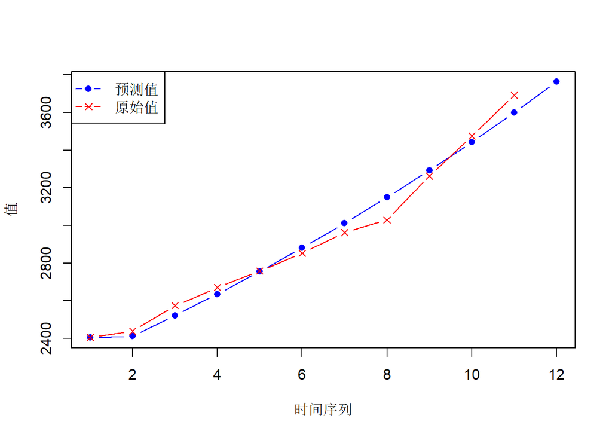

```r
#构建GM(1,1)函数
gm11<-function(x0, t){
  x1<-cumsum(x0)
  b<-numeric(length(x0)-1)
  n<-length(x0)-1
  for(i in 1:n){
    b[i]<--(x1[i]+x1[i+1])/2
    b}
  #得到GM(1,1)参数估计值并输出
  D<-numeric(length(x0)-1)
  D[]<-1
  B<-cbind(b,D)
  BT<-t(B)
  M<-solve(BT%*%B)
  YN<-numeric(length(x0)-1)
  YN<-x0[2:length(x0)]
  alpha<-M%*%BT%*%YN
  alpha2<-matrix(alpha,ncol=1)
  a<-alpha2[1]
  u<-alpha2[2]
  cat("GM(1,1)参数估计值：",'\n',"发展系数-a=",-a,"  ","灰色作用量u=",u,'\n','\n')
  #计算x(0)的模拟值
  y<-numeric(length(c(1:t)))#t为给定的预测个数
  y[1]<-x1[1]
  for(w in 1:(t-1)){
    y[w+1]<-(x1[1]-u/a)*exp(-a*w)+u/a
  }
  #输出x(0)的模拟值
  xy<-numeric(length(y))
  xy[1]<-y[1]
  for(o in 2:t){
    xy[o]<-y[o]-y[o-1]
  }
  cat("x(0)的模拟值：",'\n',xy,'\n','\n')
  #计算残差e
  e<-numeric(length(x0))
  for(l in 1:length(x0)){
    e[l]<-x0[l]-xy[l] #得残差
  }
  #计算相对误差
  e2<-numeric(length(x0))
  for(s in 1:length(x0)){
    e2[s]<-(abs(e[s])/x0[s]) #得相对误差
  }
  cat("残差平方和=",sum(e^2), '\n')
  cat("平均相对误差=",sum(e2)/(length(e2)-1)*100, "%", '\n')
  cat("相对精度=",(1-(sum(e2)/(length(e2)-1)))*100, "%", '\n', '\n')
  #后验差比值检验
  avge<-mean(abs(e));esum<-sum((abs(e)-avge)^2);evar=esum/(length(e)-1);se=sqrt(evar)
  avgx0<-mean(x0);x0sum<-sum((x0-avgx0)^2);x0var=x0sum/(length(x0));sx=sqrt(x0var)
  cv<-se/sx  #得验差比值
  cat("后验差比值检验:",'\n',"C值=",cv,'\n')#对后验差比值进行检验，与一般标准进行比较判断预测结果好坏。
  if(cv < 0.35){
    cat("C值<0.35, GM(1,1)预测精度等级为：好", '\n', '\n')
  }else{
    if(cv<0.5){
      cat("C值属于[0.35,0.5), GM(1,1)模型预测精度等级为：合格", '\n', '\n')
    }else{
      if(cv<0.65){
        cat("C值属于[0.5,0.65), GM(1,1)模型预测精度等级为：勉强合格", '\n', '\n')
      }else{
        cat("C值>=0.65, GM(1,1)模型预测精度等级为：不合格", '\n', '\n')
      }
    }
  }
  ##画出输入序列x0的预测序列及x0的比较图像
  plot(xy, col='blue', type='b', pch=16, xlab='时间序列', ylab='值')
  points(x0, col='red', type='b', pch=4)
  legend('topleft', c('预测值','原始值'), pch=c(16,4), lty=l, col=c('blue', 'red'))
}
x0<-c(2404.7,2438.1,2574.2,2671.3,2757.8,2853.4,2963.0,3029.9,3262.9,3476.0,3691.9)
gm11(x0,length(x0)+1)
```

# 5结果分析

## 5.1模型求解

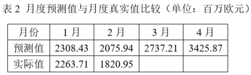